# Julie R markdown modif

Bonnefoy

2023-01-17

#### This file is regarding the results for the water stress green house experiment - Group 5

## Chapter 1 - Downloading the data

> The initial step is the aggregation of all data from the groups (1-5) in a shared Excel file on Google Drive. The dataframe is directly downloaded from GoogleDrive with the package ‘gsheet’ and named d0. Prior installation of Rtools in the right version of R is necessary to use this package.

```r
#install.packages('Rtools')
#install.packages('gsheet')
library(gsheet)
d0 <- gsheet2tbl('https://docs.google.com/spreadsheets/d/1WM6hDgwCFxbLpT37HLzU-iYZAEGBdHP6CpU8BDwWmZc/edit#gid=0', sheet = "Data")
```

> After importing the data, next step is to visualize it, by creating different plots.

## Chapter 2 - Visualization of data with plots.

> In this step we want to create many plots in order to better visualize the data. We will use X= Date and Y= Variable (Y1= Plant height ; Y2= Leaf number ; Y3= Leaf lenght ; Y4= Leaf width ; Y5= Leaf area ; Y7= Chlorophyll).

**The code used for this step is : ggplot(d0, aes(x= Date, y =Plant_height, group= PlantId, color= Treatment)) + geom_line() + facet_grid(Species ~.)**

### Findings

> After seeing all the charts, we selected only the ones below because:
> - we want to make the R markdown file visually appealing by avoiding plotting all variables for all species;
> - we consider the graphs below representative of the general trends observed in the other species and variables.
> - we have chosen to analyze the data for week 6, because the effect of the water stress deficit is clearer for this week.

> In order to get a better understanding of the variability between weeks, the group chose to explore two main graphs for soil parameters, one with a cultivated species (Solanum lycopersicum) and one with a wild species (Lolium perenne). The following code chunk is performing the visual representation.

```r
# For Solanum lycopersicum

library(viridis)
```

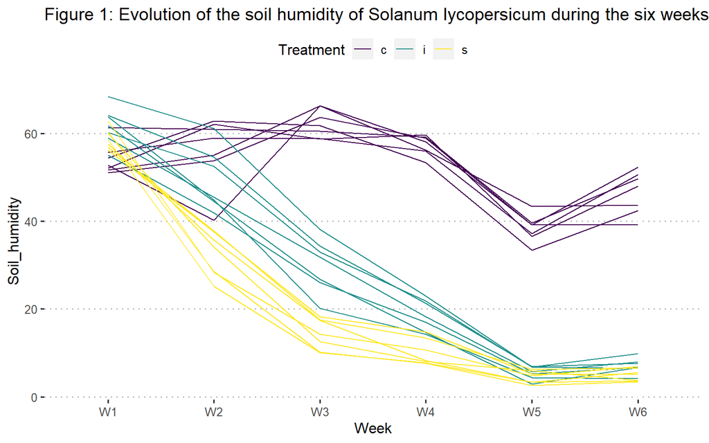

```r
s1 <- d0[d0$Species == "Solanum lycopersicum",]
ggplot(s1, aes(x= Week, y= Soil_humidity, group= PlantId, color= Treatment)) +
  geom_line() +
  labs(title = 'Figure 1: Evolution of the soil humidity of Solanum lycopersicum during the six weeks') +
  theme_pubclean() +
  scale_color_viridis(discrete = TRUE)
```

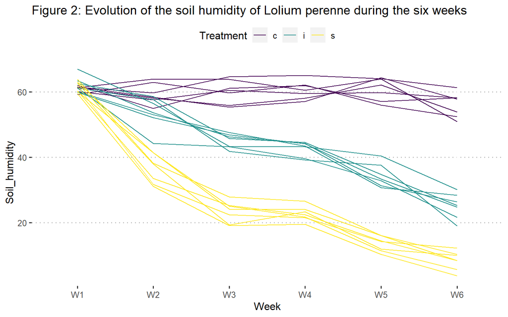

```r
# For   Lolium perenne
s2 <- d0[d0$Species=="Lolium perenne",]
ggplot(s2, aes(x= Week, y= Soil_humidity, group= PlantId, color= Treatment)) +
  geom_line() +
  labs(title = 'Figure 2: Evolution of the soil humidity of Lolium perenne during the six weeks') +
  theme_pubclean() +
  scale_color_viridis(discrete = TRUE)
```

> The next code chunk is meant to help visualize the pattern we have by taking only the variable “Plant_height” and the species Raphanus sativus. This species was the most representative species to assess the plant height by treatment, and the plant height appeared to be the best variable to extrapolate the stress level of the plant.

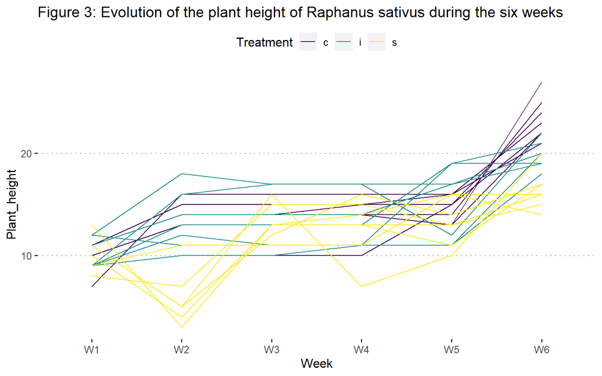

```r
# For   Raphanus sativus

s3 <- d0[d0$Species=="Raphanus sativus",]
ggplot(s3, aes(x= Week, y= Plant_height, group= PlantId, color= Treatment)) +
  geom_line() +
  labs(title = 'Figure 3: Evolution of the plant height of Raphanus sativus during the six weeks') +
  theme_pubclean() +
  scale_color_viridis(discrete = TRUE)
```

> It appears that the treatment has an influence on the height of the plant. In week 2 we can see the difference clearly between the well-watered and the water-stressed plants where the plant height is increasing in control and intermediate but decreasing under stress conditions. The following weeks evolution depends a lot on the repetition, and the variability belong them is high. Week 6 is determining the influence of the treatment on radish growth: it will peak above 20cm for the well-watered plants, between 15 and 20cm for the intermediate treated plants, and on average 15cm for the water-stressed plants.

> For the third part of this project, we will advance with statistical analyses. For this we will use multiple packages including “ggplot2”, “ggpubr”, “tidyverse”, “broom” and “AICcmodavg”. Now that we have seen all the variables and the difference for species over time, as we will focus on Week 6 because it appeared to be the most deciding week.

# Chapter 3 - ANOVA

> To compare the mean values of more than two groups we use an ANOVA (Analyse of Variance). Notice that to do so we made three assumptions on the data: (1) the responses for each factor level have a normal population distribution, (2) these distributions have the same variance, (3) the data are independent.

> First the ANOVA uses a linear model and so in R it needs the function lm() to perform. Next the ANOVA will need a test of significance - in addition to the ANOVA test - to determine the relationship between the sets of data. Here The Tukey HSD (“honest significant difference”) test will specify (with letters) the pair of data that causes the difference.

## Linear model

### Plant Height

```r
# Performing the ANOVA analysis

d1 <- d0[d0$Week == "W6" , c("Treatment", "Species", "Plant_height") ]
d1 <- na.exclude(d1) #remove the ones with empty cells
lm1 <- lm(Plant_height ~ Treatment + Species, data=d1)
anova(lm1)
```

```
## Analysis of Variance Table
##
## Response: Plant_height
##            Df Sum Sq Mean Sq  F value  Pr(>F)
## Treatment   2    449   224.6   7.2916 0.00088 ***
## Species     8  59800  7475.0 242.7219 < 2e-16 ***
## Residuals 198   6098    30.8
## ---
## Signif. codes:  0 '***' 0.001 '**' 0.01 '*' 0.05 '.' 0.1 ' ' 1
```

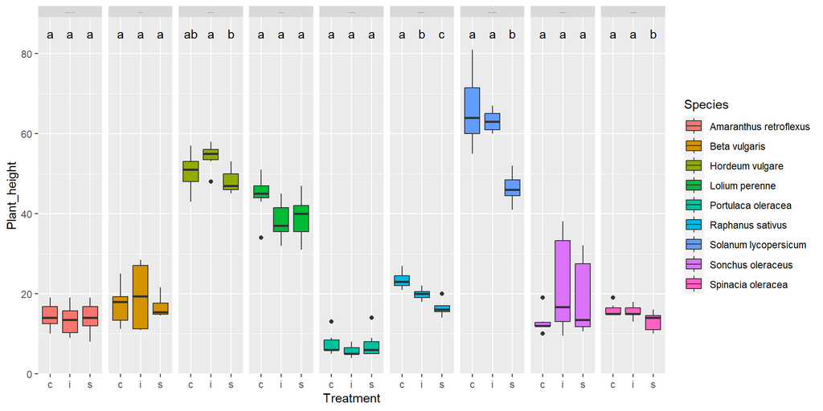

```r
# Performing  Tukey HSD analysis

# The objective here is create a table using a for loop function, and fill it with the results of Tukey HSD (letters), and automatically assign these letters to the box plots for each species.

rl <- length(levels(as.factor(d0$Species)))*3  #number of rows

df0 <- data.frame(Treatment = character(), Species = character(), Letters = character())
df0[1:rl,] <- NA
k = 1
i <- levels(as.factor(d0$Species))[1]
for (i in levels(as.factor(d0$Species))) {


d2 <- d1[d1$Species == i,]

model <- aov(Plant_height~Treatment, data =d2 )

hsd <- HSD.test(model, "Treatment")

df0$Treatment[k:(k+2)] <- row.names(hsd$groups)
df0$Species [k:(k+2)] <- i
df0$Letters [k:(k+2)] <- hsd$groups$groups

k <- k+3
}


# plotting the ANOVA results

ggplot(d1, aes(x= Treatment, y= Plant_height, fill= Species)) +
  geom_boxplot() +
  facet_grid(. ~ Species) +
  theme(strip.text.x = element_text(size=0)) +
  geom_text(data =df0 , aes(y = 85, label = Letters))
```

### Soil_humidity

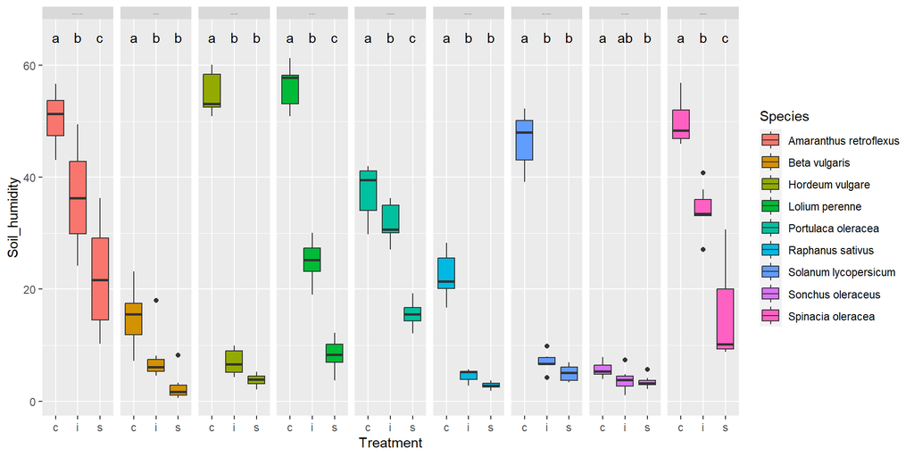

### Leaf_number

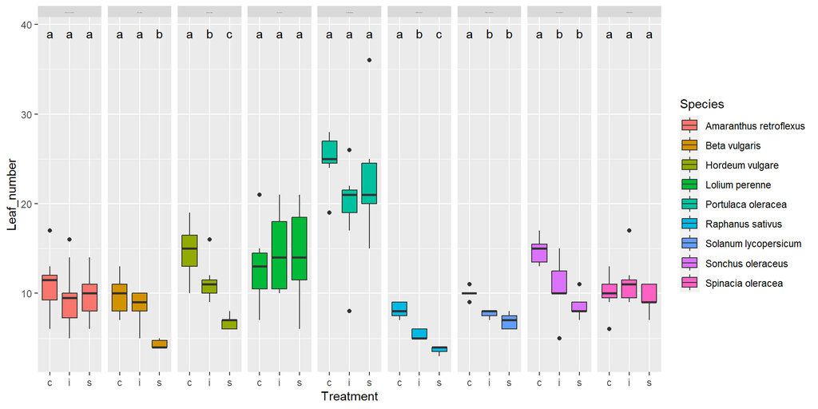

### Leaf_length

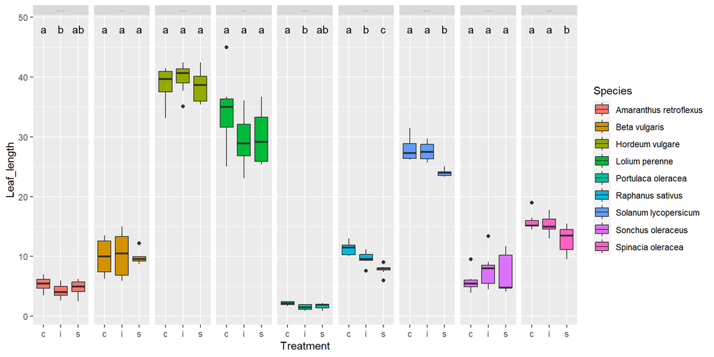

### Leaf_width

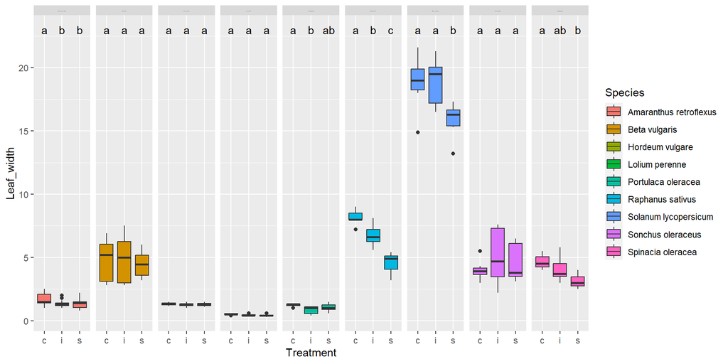

### Leaf_area

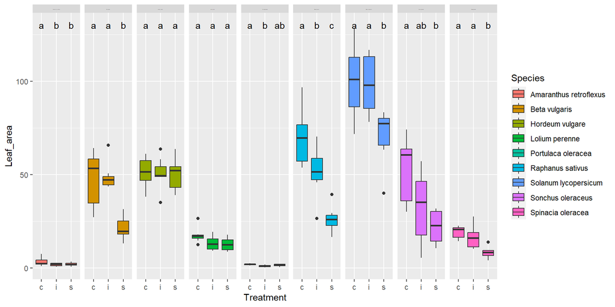

### Aerial_fresh_weight

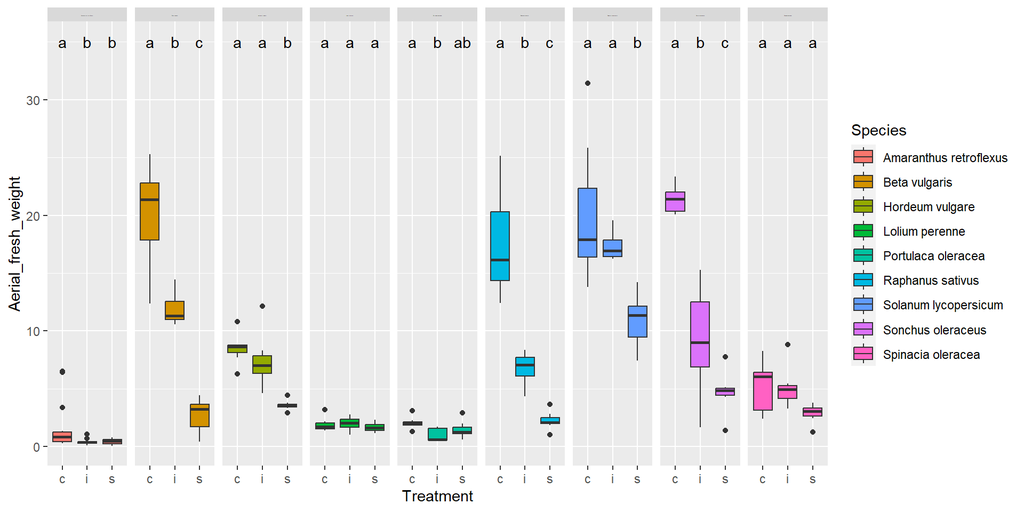

### Aerial_dry_weight

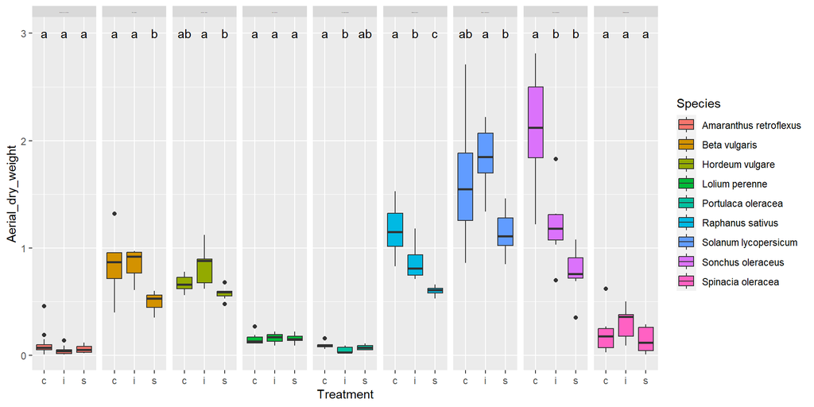

### Roots_fresh_weight

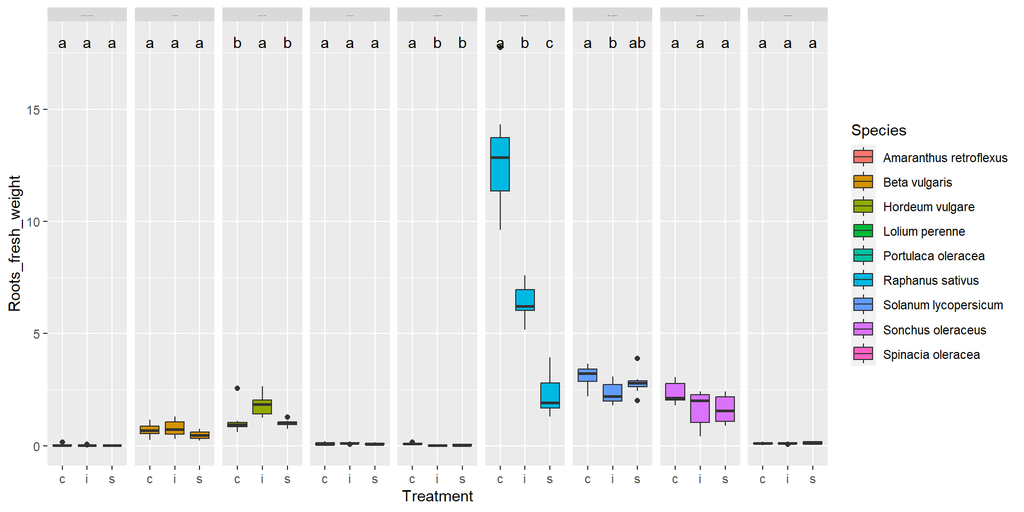

### Roots_dry_weight

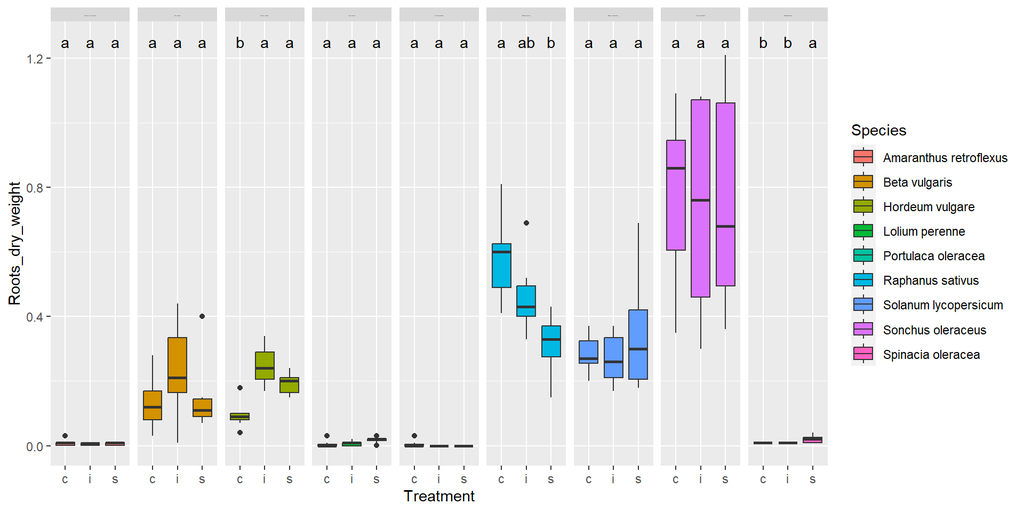